# Data Analytics Final Project Report

Zharkov, Oleksii (h12046515); Fiege, Moritz Johannes (h12319734); Sultanbekova, Daryia (h12351729); Janabayev, Alikhan (h12044122)

2025-12-15

# Data Project Group 4:

## Food and agricultural Imports and Exports auf Austria in Year 20203

#### Source of dataset: https://www.fao.org/faostat/en/#data/TM

## General overview of project:

### Reserach Questions:

#### Are imports or exports greater from EU or non-EU?

#### Are imports or exports greater from neighboring countires?

#### What are Austrias most imported / exported goods?

#### Which countires have similar trade patterns?

#### What are general patterns characterize Austria’s trade profile in 2023?

## Applied Methods:

#### For reasearching the research questions we decided to implement the following Methods: Comparative aggregation, Group comparison, Descriptive ranking, K-means clustering and Principal compenent Analysis. To categorize we use descripitve statistics, Comparative Analysis and clustering.

## Business Understanding:

#### The purpose of the project is to see which trading partners and which products are most important to the austrian food market. This case gets handeld with to some describitve Methods as well as some clustering methods as we already described. With the results of these it makes it easier for politcs as well as for companies who are in business of trading or producing with food or agricultural products to prioratize countries or firms who are within some countries.

#### We used the following libraries to accomplish our project.

```r
library(ggplot2)
library(readr)
library(scales)
library(stringr)
library(dbscan)
```

#### We used ggplot2 for plotting our graphs, readr to read our data in, scales to have prettier scales for our PCA plot and stringr to cut off strings in plots for better readability and dbscan to perform clustering with dbscan.

## Reading Data in, cleaning it and get an overview of the data

```r
# Read in data form csv file
trade_raw <- read.csv("./FAOSTAT_data_en_11-17-2025-2.csv")

## Get count of missing data -> should be zero
total_na_count <- sum(is.na(trade_raw))
print("Amount of NA and NaN in data")
```

```
## [1] "Amount of NA and NaN in data"
```

```r
total_na_count
```

```
## [1] 0
```

```r
# Clean strings:
names(trade_raw) <- tolower(names(trade_raw)) # Convert names to lowercase
names(trade_raw) <- gsub("[^[:alnum:]]", "_", names(trade_raw)) # Replace every symbol that is not number or char to _

# Restore data with easier name
trade <- trade_raw

# Inspect structure
print("Dimensions of Data")
```

```
## [1] "Dimensions of Data"
```

```r
dim(trade)
```

```
## [1] 35491    16
```

```r
head(trade)
```

```
##   domain_code                domain reporter_country_code__m49_
## 1          TM Detailed trade matrix                          40
## 2          TM Detailed trade matrix                          40
## 3          TM Detailed trade matrix                          40
## 4          TM Detailed trade matrix                          40
## 5          TM Detailed trade matrix                          40
## 6          TM Detailed trade matrix                          40
##   reporter_countries partner_country_code__m49_ partner_countries element_code
## 1            Austria                          4       Afghanistan         5610
## 2            Austria                          4       Afghanistan         5622
## 3            Austria                          4       Afghanistan         5610
## 4            Austria                          4       Afghanistan         5622
## 5            Austria                          4       Afghanistan         5610
## 6            Austria                          4       Afghanistan         5622
##           element item_code__cpc_
```

[output cut: 20 more lines]

#### The data in general can be considered clean, since there are no NA or NaNs. Therefore we only adapt the strings to make them more unique. We can generally assume that there are not outliers, since the Faostat is a highly recognized source and every datapoint is legitament to generally proof that a data point is an outlier we would need to counterproof that by comparing every countrie and every product with another data source and this would generally be too much to proove.

## Initializing subset

```r
# Creating subset where we only keep Import/Export Value and drop Import/Export quanitiy
trade_2023 <- subset(trade,
  reporter_countries == "Austria" &
  unit == "1000 USD" &
  element %in% c("Import value", "Export value")
)

# Create new column named flow in subset to store either Import, Export or NA when no specification is made
trade_2023$flow <- NA_character_
trade_2023$flow[trade_2023$element == "Import value"] <- "Import"
trade_2023$flow[trade_2023$element == "Export value"] <- "Export"

# See changed data
table(trade_2023$flow) # See how many are Imports and how many are Exports
```

```
##
## Export Import
##  10577   7218
```

```r
head(trade_2023)
```

```
##    domain_code                domain reporter_country_code__m49_
## 2           TM Detailed trade matrix                          40
## 4           TM Detailed trade matrix                          40
## 6           TM Detailed trade matrix                          40
## 8           TM Detailed trade matrix                          40
## 10          TM Detailed trade matrix                          40
## 12          TM Detailed trade matrix                          40
##    reporter_countries partner_country_code__m49_ partner_countries element_code
## 2             Austria                          4       Afghanistan         5622
## 4             Austria                          4       Afghanistan         5622
## 6             Austria                          4       Afghanistan         5622
## 8             Austria                          4       Afghanistan         5622
## 10            Austria                          4       Afghanistan         5622
## 12            Austria                          4       Afghanistan         5622
##         element item_code__cpc_
```

[output cut: 20 more lines]

## Define list with all names of eu_countires and neighbors and categorize countires

```r
# Defining a vector containing all current EU member states
eu_countries <- c(
  "Austria","Belgium","Bulgaria","Croatia","Cyprus","Czechia",
  "Denmark","Estonia","Finland","France","Germany","Greece",
  "Hungary","Ireland","Italy","Latvia","Lithuania","Luxembourg",
  "Malta","Netherlands","Poland","Portugal","Romania",
  "Slovakia","Slovenia","Spain","Sweden"
)

# Defining a vector of countries that share a border with Austria
neighbors <- c(
  "Germany","Czechia","Slovakia","Hungary",
  "Slovenia","Italy","Switzerland","Liechtenstein"
)

# Categorizing countries who are in the EU and not in the EU and store results in column partner_is_eu by comparing country name with list
trade_2023$partner_is_eu <- ifelse(trade_2023$partner_countries %in% eu_countries, "EU", "non-EU")

# Categorizing countries who are neighbors and not neighbors to Austria and store results in column neighbor by comparing country name with list
trade_2023$neighbor <- ifelse(trade_2023$partner_countries %in% neighbors, "Neighbor", "Non-neighbor")
```

#### To categorize countries we decided that it would be best to use logical operators (ifelse) to check wheter a country is in the defined list of neighbor or Eu country.

## Comparison of EU and non-EU countires in exports and imports

```r
# 4. Compare import and exports from non-/EU

# Calculate the total trade value for each combination of Flow (Import/Export) and Region (EU/Non-EU)
eu_non_eu_by_flow <- aggregate(
  value ~ flow + partner_is_eu,
  data = trade_2023,
  FUN = sum
)
# Rename the sum column for clarity
names(eu_non_eu_by_flow)[names(eu_non_eu_by_flow) == "value"] <- "total_value"

# Display the summary table to check the calculated totals
eu_non_eu_by_flow
```

```
##     flow partner_is_eu total_value
## 1 Export            EU    13522993
## 2 Import            EU    14803934
## 3 Export        non-EU     4297158
## 4 Import        non-EU     3865633
```

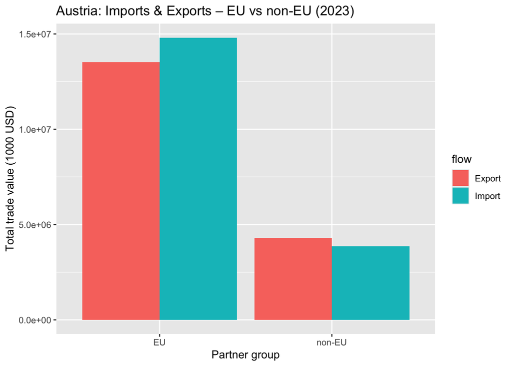

```r
# Create a bar chart to compare the totals
ggplot(eu_non_eu_by_flow,
       aes(x = partner_is_eu, y = total_value, fill = flow)) +
  geom_col(position = "dodge") +
  labs(
    x = "Partner group",
    y = "Total trade value (1000 USD)",
    title = "Austria: Imports & Exports – EU vs non-EU (2023)"
  )
```

#### This graph reveals that Austria’s economy is heavily EU-centric. The volume of trade within the EU (left) is roughly three times larger than trade with the rest of the world (right). Additionally, the trade balance flips: Austria is a net importer within the Single Market (buying more than it sells), but operates as a net exporter when trading with non-EU countries.

#### To answer the research question whether more imports and exports are happening from EU-Countries the answer is yes.

## Comparison of Neighboring countries and non Neighboring countires in exports and imports

```r
# 5.Compare import and exports from Neighbors vs Non-neighbors

# Calculate total trade value grouped by Flow (Import/Export) and Neighbor status
neighbors_by_flow <- aggregate(
  value ~ flow + neighbor,
  data = trade_2023,
  FUN = sum
)
# Rename the sum column for clarity
names(neighbors_by_flow)[names(neighbors_by_flow) == "value"] <- "total_value"

# Display the summary table to inspect the calculated numbers
neighbors_by_flow
```

```
##     flow     neighbor total_value
## 1 Export     Neighbor    11234288
## 2 Import     Neighbor    12672210
## 3 Export Non-neighbor     6585863
## 4 Import Non-neighbor     5997357
```

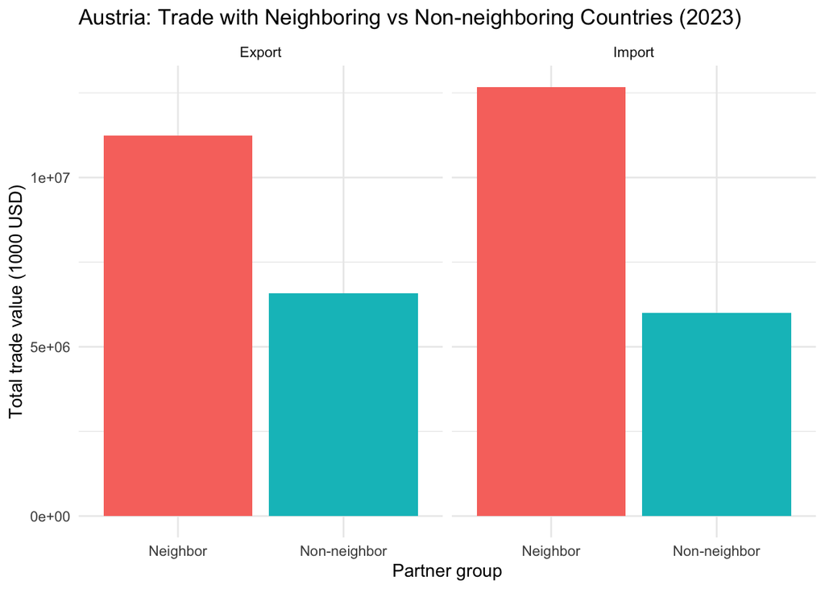

```r
# Visualize the comparison with a side-by-side bar chart
ggplot(neighbors_by_flow,
       aes(x = neighbor, y = total_value, fill = neighbor)) +
  geom_col() +
  facet_wrap(~ flow) +   # Create separate panels for imports and exports
    # Add axis labels and a descriptive title
  labs(
    x = "Partner group",
    y = "Total trade value (1000 USD)",
    title = "Austria: Trade with Neighboring vs Non-neighboring Countries (2023)"
  ) +
  theme_minimal() +
  theme(legend.position = "none")
```

#### Research Question examines whether Austria’s imports and exports are higher when trading with neighboring countries compared to non-neighboring countries in 2023. Using our dataset, Austria’s trade flows were grouped into imports and exports and further classified according to whether the trading partner shares a geographical border with Austria. This allows for a direct comparison of trade volumes based on geographical proximity.As we can see in our graph, neighboring countries account for a larger share of both imports and exports. Therefore, we can make a conclusion that Austria’s imports and exports are higher when trading with neighboring countries compared to non-neighboring countries in 2023.

#### To answer the research question whether more imports and exports are happening from neighboors the answer is also yes.

## Calculating share of total trade within each trade flow

```r
# Calculate the share of total trade within each trade flow (imports and exports)
neighbors_by_flow$share <- ave(
  neighbors_by_flow$total_value,  # Total trade values used for the calculation
  neighbors_by_flow$flow, #calculations are done separately for imports and exports
  FUN = function(x) x / sum(x)   # Function to compute each group's share of the total trade
)

neighbors_by_flow #display results
```

```
##     flow     neighbor total_value     share
## 1 Export     Neighbor    11234288 0.6304261
## 2 Import     Neighbor    12672210 0.6787629
## 3 Export Non-neighbor     6585863 0.3695739
## 4 Import Non-neighbor     5997357 0.3212371
```

#### Using FAOSTAT trade data for Austria in 2023, trade flows were aggregated by partner type (neighboring vs non-neighboring countries) and by trade flow (imports and exports). The results show that neighboring countries account for the majority of Austria’s trade. Approximately 63.0% of Austria’s total exports are directed to neighboring countries, while 67.9% of total imports originate from them. In contrast, non-neighboring countries account for only 37.0% of exports and 32.1% of imports. These results prove that geographical proximity plays a big role in Austria’s trade.

## Comparing and identifing most imported and most exported products

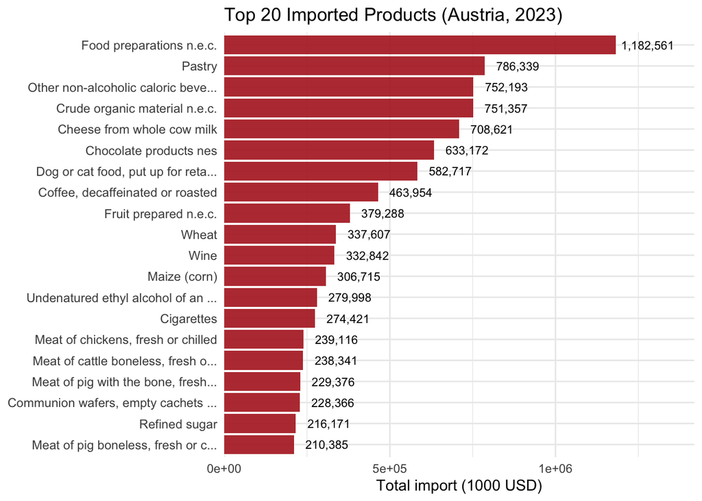

```r
# Sort in subset for col flow where they import goods and store in new temp data frame
import_data <- subset(trade_2023, flow == "Import")

# Using aggregate to aggregate and group items
top_import_items <- aggregate(
  value ~ item, # Sum value col grouped by item col
  data = import_data,
  FUN = sum # Aggregate function is sum
)

# Change name for better understanding what we did
names(top_import_items)[names(top_import_items) == "value"] <- "total_import_value"

# Sort top_imported_items in descending order by minus sign
top_import_items <- top_import_items[order(-top_import_items$total_import_value), ]

# Drop countries who are not in the top 20
top_import_items <- head(top_import_items, 20)

# Cut off name of goods after 35 characters and add "..." for better readability by using slicer
top_import_items$item <- str_trunc(top_import_items$item, width = 35, side = "right")

# Plot top 20 imported items with ggplot
ggplot(top_import_items,
       aes(x = reorder(item, total_import_value),
           y = total_import_value)) +
  geom_col(fill = "firebrick", alpha = 0.9) +

  # Add numbers at the end of bars
  geom_text(aes(label = format(total_import_value, big.mark = ",")),
            hjust = -0.1, size = 3) +

  # Flip x and y axis to get horizontal bar chart
  # Did this for better readability of names of products
  coord_flip() +

  # Add space for labels
  scale_y_continuous(expand = expansion(mult = c(0, 0.2))) +

  labs(
    x = NULL, # Remove x axis label
    y = "Total import (1000 USD)",
    title = "Top 20 Imported Products (Austria, 2023)"
  ) +
  theme_minimal() +
  theme(axis.text.y = element_text(size = 9))
```

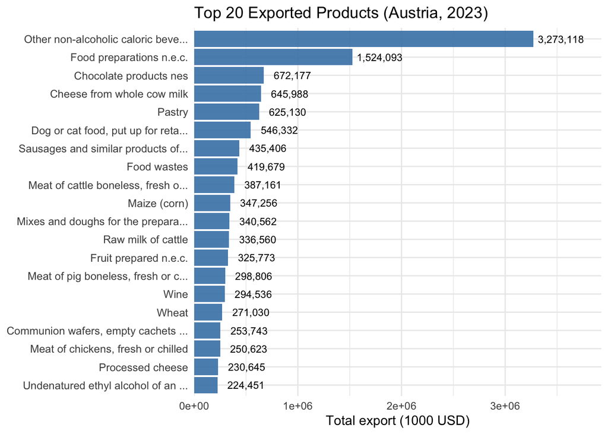

```r
# Exported products
# Repeating the steps above only now with Exports

# Sort in subset for col flow where they exported goods and store in new temp data frame
export_data <- subset(trade_2023, flow == "Export")

# Using aggregate to aggregate and group items
top_export_items <- aggregate(
  value ~ item, # Sum value col grouped by item col
  data = export_data,
  FUN = sum # Aggregate function is sum
)

# Change name for better understanding what we did
names(top_export_items)[names(top_export_items) == "value"] <- "total_export_value"

# Sort top_exported_items in descending order by minus sign
top_export_items <- top_export_items[order(-top_export_items$total_export_value), ]

# Drop countries who are not in the top 20
top_export_items <- head(top_export_items, 20)

# Cut off again name of goods after 35 characters and add "..." for better readability by using slicer
top_export_items$item <- str_trunc(top_export_items$item, width = 35, side = "right")

# Plot top 20 exported items with ggplot
ggplot(top_export_items,
       aes(x = reorder(item, total_export_value),
           y = total_export_value)) +
  geom_col(fill = "steelblue", alpha = 0.9) +

  geom_text(aes(label = format(total_export_value, big.mark = ",")),
            hjust = -0.1, size = 3) +

  # Flip x and y axis to get horizontal bar chart
  # Did this for better readability of names of products
  coord_flip() +
    # Add space for labels
  scale_y_continuous(expand = expansion(mult = c(0, 0.2))) +

  labs(
    x = NULL, # Remove x axis label
    y = "Total export (1000 USD)",
    title = "Top 20 Exported Products (Austria, 2023)"
  ) +
  theme_minimal() +
  theme(axis.text.y = element_text(size = 9))
```

#### Exported Products: By far the most exported product is non alcoholic beverages. It exports much more that it imports. Processed and Prepared Foods play as well a huge role in the exported goods. for example Choclate, Pastry, Sausages and similar products.

#### Comparison: The imported products lean more towards finished consumer goods, which dont need any further processing. The other most important imported category for goods is basic raw materials like wheat, maize and so on. Exports in comaprison lean strongly towards beverages like the non alcoholic beverages where we clearly export more than we import.

## Aggregation and Transformation of Trade Data for Clustering Analysis

```r
# Summarising the total trade value per country and product category
country_item_summary <- aggregate(
  value ~ partner_countries + item,
  data = trade_2023,
  FUN = sum
)
names(country_item_summary)[names(country_item_summary) == "value"] <- "total_trade_value"

# Transforming the data so that:
# - each unique partner country becomes one row
# - each unique item(trading good) becomes a separate column
# - reshaping the data into a country × product matrix
country_item_matrix <- reshape(
  country_item_summary,
  idvar = "partner_countries",
  timevar = "item",
  direction = "wide",
  v.names = "total_trade_value"
)

# Replacing NA with zero trade values(no trade)
country_item_matrix[is.na(country_item_matrix)] <- 0

# Storing country names
country_names <- country_item_matrix$partner_countries

# Removing the country column for pca and clustering and cleaning the column names
X <- country_item_matrix[, -1]
names(X) <- gsub("total_trade_value.", "", names(X))

# Using logarithmic transformation to reduce skewness and and stabilize variance
X_log <- log1p(X)
```

#### This code prepares our trade data for further analysis by:

#### - summing the total trade values for each partner country and product

#### - reshaping the data so that each country is represented as a row and each product as a separate column

#### - zero values indicating no zero trade

#### - logarithmic transformation to reduce the extreme differences(like with Germany)

## Computing the PCA

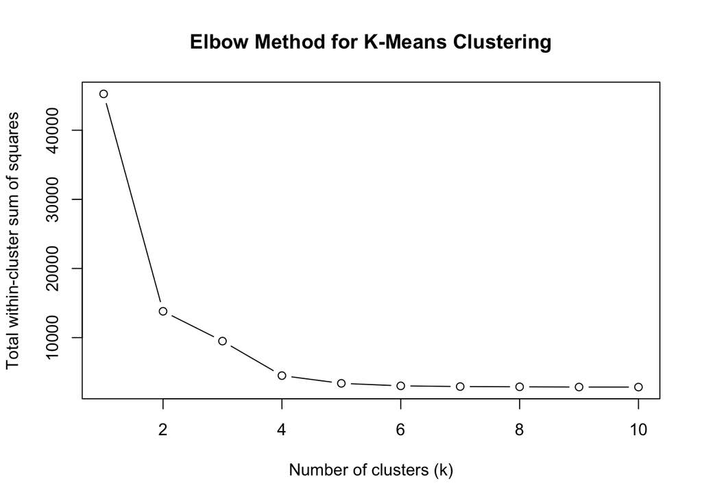

```r
# Computing the variance for each column and using only >0 values that show trade that actually differ between counties
col_vars <- apply(X_log, 2, function(z) var(z, na.rm = TRUE))
X_pca <- X_log[, col_vars > 0, drop = FALSE]

# Compunting PCA on the cleaned matrix
pca_res <- prcomp(X_pca, center = TRUE, scale. = TRUE)

# Creating a data frame with country names and the first two PCA coordinates
pca_df <- data.frame(
  country = country_names,
  PC1 = pca_res$x[, 1],
  PC2 = pca_res$x[, 2]
)

# Calculating the total trade volume
pca_df$total_volume <- rowSums(X)
# Ranking countries by total trade volume in desc order
pca_df$rank <- rank(-pca_df$total_volume)

# Shortening some country names for better readability later in plots
pca_df$short_name <- as.character(pca_df$country)
pca_df$short_name[pca_df$short_name == "United Kingdom of Great Britain and Northern Ireland"] <- "UK"
pca_df$short_name[pca_df$short_name == "United States of America"] <- "USA"
pca_df$short_name[pca_df$short_name == "Netherlands (Kingdom of the)"] <- "Netherlands"
pca_df$short_name[pca_df$short_name == "Russian Federation"] <- "Russia"
pca_df$short_name[pca_df$short_name == "China, mainland"] <- "China"
pca_df$short_name[pca_df$short_name == "Bosnia and Herzegovina"] <- "Bosnia"

# We will use only top 25 countries by trade also for better representation
pca_df$label_text <- ifelse(pca_df$rank <= 25, pca_df$short_name, "")

set.seed(123)
wss <- numeric()  # within-cluster sum of squares

for (i in 1:10) {
  wss[i] <- kmeans(pca_res$x[, 1:2], centers = i)$tot.withinss
}

# Plotting the elbow curve to determine the number of k
plot(
  1:10, wss, type = "b",
  xlab = "Number of clusters (k)",
  ylab = "Total within-cluster sum of squares",
  main = "Elbow Method for K-Means Clustering"
)
```

```r
# The elbow curve flattens around k = 4, which is chosen as the number of clusters.
k <- 4

# Kmeans
my_clusters <- kmeans(pca_res$x[, 1:2], centers = k)
pca_df$cluster <- as.factor(my_clusters$cluster)
```

#### The elbow curve flattens around k = 4, which is chosen as the number of clusters.

## Visualisation of PCA Results and Clustering on a Scatterplot

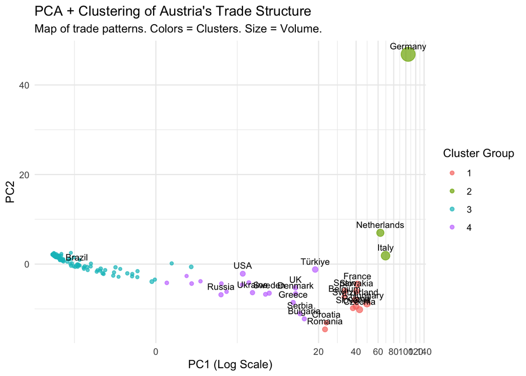

```r
print(
  ggplot(pca_df, aes(x = PC1, y = PC2, label = label_text)) +
    geom_point(aes(size = total_volume, color = cluster), alpha = 0.7) +
    geom_text(size = 3, vjust = -0.8, check_overlap = FALSE) +
    scale_x_continuous(trans = "pseudo_log", breaks = pretty_breaks(n=10)) +
    scale_size_continuous(guide = "none") +
    labs(
      title = "PCA + Clustering of Austria's Trade Structure",
      subtitle = "Map of trade patterns. Colors = Clusters. Size = Volume.",
      x = "PC1 (Log Scale)", y = "PC2", color = "Cluster Group"
    ) +
    theme_minimal()
)
```

## Cluster Profiles shown in the Bar Plot

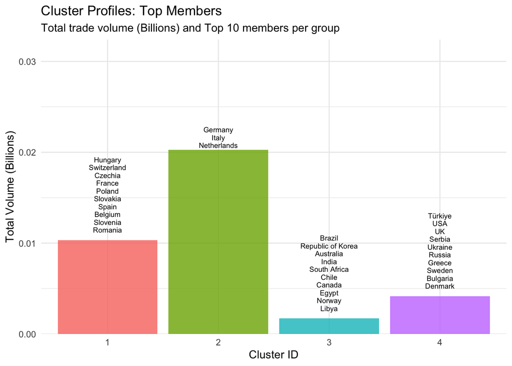

```r
# Splitting data by cluster
split_by_cluster <- split(pca_df, pca_df$cluster)

# Creating a cluster summary table:
# - total trade volume of the cluster
# - top 10 countries inside the cluster by total trade volume
cluster_profile <- do.call(rbind, lapply(split_by_cluster, function(df) {
   # Calculating total trade volume for the cluster and converting it to billions
  volume_bn <- sum(df$total_volume) / 1e9

  # Sorting the countries
  df_sorted <- df[order(-df$total_volume), ]
  top_members <- paste(head(df_sorted$short_name, 10), collapse = "\n")

  # Saving cluster ID, total volume and top members into a data frame
  data.frame(
    cluster = df$cluster[1],
    Volume_Bn = volume_bn,
    Top_Members = top_members
  )
}))

# Plotting
print(
  ggplot(cluster_profile, aes(x = cluster, y = Volume_Bn, fill = cluster)) +
    geom_col(alpha = 0.8) +

    geom_text(aes(label = Top_Members),
              vjust = -0.1, # Sit slightly above the bar
              size = 2.5,   # Smaller text to fit 10 names
              lineheight = 0.9) +
    scale_y_continuous(expand = expansion(mult = c(0, 0.6))) +
    labs(
      title = "Cluster Profiles: Top Members",
      subtitle = "Total trade volume (Billions) and Top 10 members per group",
      x = "Cluster ID",
      y = "Total Volume (Billions)"
    ) +
    theme_minimal() +
    theme(legend.position = "none")
)
```

#### - This plot provides a different representation of the clustering results using a bar plot for clearer and more visually appealing presentation. It shows the total trade volume of each cluster and lists the top ten trading partners within each group (the second cluster only has three partners so it only shows them).

#### - Cluster 2 clearly dominates Austria’s trade, mainly due to major partners such as Germany, Italy, and the Netherlands

#### - Cluster 1 and 4 represent medium-sized groups with a mix of European and international partners.

#### - Cluster 3 has the smallest total trade volume and consists mostly of more distant and/or less important trading partners.

## Alternative Clustering: K-means on Scaled Log-Data

```r
# Removing zero-variance columns
col_vars <- apply(X_log, 2, function(z) var(z, na.rm = TRUE))
X_nzv <- X_log[, col_vars > 0, drop = FALSE]

# Scaling the log-transformed data
X_scaled <- scale(as.matrix(X_nzv))

set.seed(123)
k <- 4

km_res <- kmeans(X_scaled, centers = k, nstart = 25)

clusters_df <- data.frame(
  country = country_names,
  cluster = factor(km_res$cluster)
)
clusters_df[order(clusters_df$cluster), ]
```

```
##                                                   country cluster
## 2                                                 Belgium       1
## 3                                                 Czechia       1
## 4                                                  France       1
## 6                                                 Hungary       1
## 13                                                 Poland       1
## 14                                               Slovakia       1
## 15                                               Slovenia       1
## 16                                                  Spain       1
## 17                                            Switzerland       1
## 8                                                 Ireland       2
## 18                                                Türkiye       2
## 19                                                Ukraine       2
## 20   United Kingdom of Great Britain and Northern Ireland       2
## 24                                               Bulgaria       2
```

[output cut: 169 more lines]

#### This table shows the results of a different k-means clustering approach. Here countries are grouped based on their full log-transformed and scaled trade profiles rather than on PCA coordinates. This alternative approach serves mostly as a robustness check and confirms that the main clustering results are not driven only the PCA representation. It shows the clearest structured plot to the research question which countries have similar trade patterns.

## Clustering with DB Scan

```r
# Setting seed for reproducible results
set.seed(123)

# Running db scan
# choosing an eps by trial error and see which gives the "best" results
db_res <- dbscan(pca_res$x[, 1:2], eps = 0.5)

# Dataframe to store DBSCAN results and merge with PCA data
pca_df_dbscan <- pca_df
pca_df_dbscan$dbscan_cluster <- as.factor(db_res$cluster)

# Found clusters
table(pca_df_dbscan$dbscan_cluster)
```

```
##
##   0   1   2   3
##  58  14   5 106
```

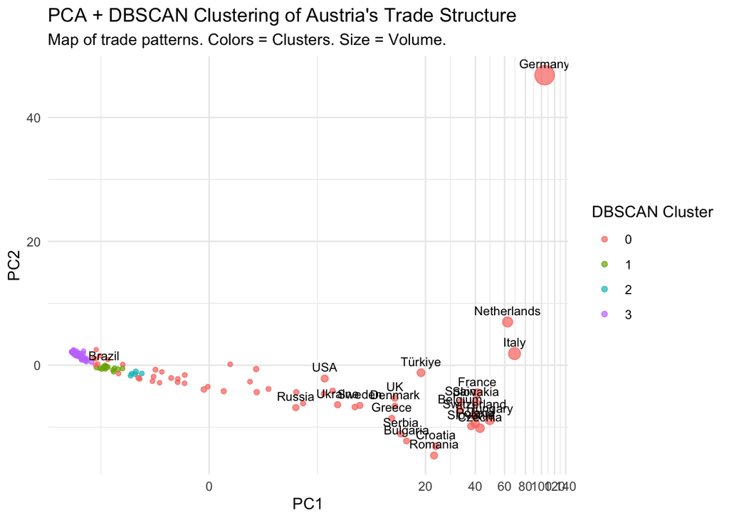

```r
# Plotting
print(
  ggplot(pca_df_dbscan, aes(x = PC1, y = PC2, label = label_text)) +
    # cluster-ID 0 is noise
    geom_point(aes(size = total_volume, color = dbscan_cluster), alpha = 0.7) +
    geom_text(size = 3, vjust = -0.8, check_overlap = FALSE) +
    scale_x_continuous(trans = "pseudo_log", breaks = pretty_breaks(n=10)) +
    scale_size_continuous(guide = "none") +
    labs(
      title = "PCA + DBSCAN Clustering of Austria's Trade Structure",
      subtitle = "Map of trade patterns. Colors = Clusters. Size = Volume.",
      x = "PC1", y = "PC2", color = "DBSCAN Cluster"
    ) +
    theme_minimal()
)
```

#### We have applied DB scan but it didnt dilver proper results. This is because the datapoints are too spread out. We make it seem due to the pseudo log that the points are closer together. But infact the points are really spread out. There also shouldnt be any outliers, since all countries are valid observation with no observation error or something similar (as we assumed in the beginning).

#### When we compare k-means clustering to DB-scan K-means is doing a far better job and we think that k-means is closer to correct clustering.

## Aggregating the top 20 trade partners by trade volume

```r
# Aggregating total trade by partner country
top_countries_trade <- aggregate(
  value ~ partner_countries,
  data = trade_2023,
  FUN = sum
)

# Rename column for clarity
names(top_countries_trade)[2] <- "total_trade_value"

# Sort countries by total trade value (descending)
top_countries_trade <- top_countries_trade[
  order(-top_countries_trade$total_trade_value),
]

top_countries_trade <- head(top_countries_trade, 20)

top_countries_trade
```

```
##                                        partner_countries total_trade_value
## 66                                               Germany          14289219
## 84                                                 Italy           3756283
## 118                         Netherlands (Kingdom of the)           2210972
## 76                                               Hungary           1779964
## 161                                          Switzerland           1460799
## 44                                               Czechia           1256502
## 61                                                France           1099600
## 134                                               Poland           1093639
## 168                                              Türkiye            830002
## 152                                             Slovakia            796293
## 156                                                Spain            712945
## 15                                               Belgium            676660
## 153                                             Slovenia            567438
## 139                                              Romania            528151
## 175                             United States of America            524310
## 41                                               Croatia            366126
## 173 United Kingdom of Great Britain and Northern Ireland            316885
## 148                                               Serbia            295995
## 171                                              Ukraine            273466
## 140                                   Russian Federation            267014
```

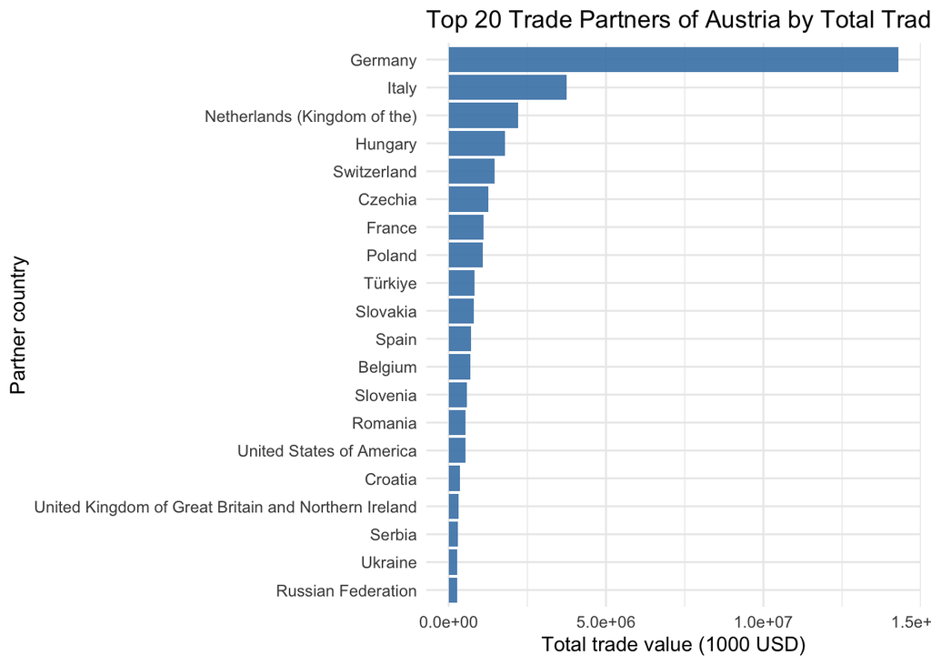

```r
# Plotting
ggplot(top_countries_trade,
       aes(x = reorder(partner_countries, total_trade_value),
           y = total_trade_value)) +
  geom_col(fill = "steelblue", alpha = 0.9) +
  coord_flip() +
  labs(
    x = "Partner country",
    y = "Total trade value (1000 USD)",
    title = "Top 20 Trade Partners of Austria by Total Trade Volume (2023)"
  ) +
  theme_minimal()
```

#### This figure shows the top 20 trade partners of Austria in 2023 ranked by total trade volume, defined as the sum of imports and exports. The results indicate that Austria’s trade is strongly concentrated among a small number of countries, with Germany clearly dominating as the most important partner. Most of the top trade partners are European countries, many of which are geographically close to Austria, highlighting the role of regional integration and proximity in trade relationships.

## Future work:

#### Further projects could focus on comparison with other years. We could then analyze how clusters change or how trade volume of specific countries or specific products change over the years. It could also be very interesting how trade in agricultural products change when for example the covid crisis hit. To conduct these future projects we would again choose a dataset from Faostat, since it is a reliable and highly recognized institution for it. Another project is to look at the top 10 most important trade partners and see if austria is as importent to them as the other country is to us.